# Homework_3

Isaac Rosenthal

September 23, 2016

# 0. Load libraries in to R. make sure working directory is set up as well.

```r
library(readr)
library(plyr)
library(dplyr)
```

```r
library(ggplot2)
library(forcats)
library(gganimate)
library(ggthemes)
library(viridis)
library(RColorBrewer)
#setwd("C:/irose/OneDrive/UMB/datasci/homework_2016/2016_homework_03_ggplot2") #only works the first time
```

# 1.1 Using the an approximate method, provide a rough 95% confidience interval for the mean.

First, we must load the data. I’ll use the `readr` package for improved functionalty when importing csvs

```r
genes <- read_csv("./data/04q11NumberGenesRegulated.csv") #readr is bestr
```

# 1a

Then, we need to find the standard deviation of the number of genes regulated by a regulatory gene.

```r
std_dev <- sd(genes$frequency) #find the SD of the data
std_dev
```

```
## [1] 4.12814
```

We can then calculate standard error by dividing the standard deviation by the square root of the number of samples

```r
std_err <- std_dev/(sqrt(length(genes$frequency))) #order of operations is important here, don't be a fool
std_err
```

```
## [1] 0.8095948
```

A simple approximation of the 95% confidence interval can be calculated by multiplying the standard error by 2.

```r
std_err * 2
```

```
## [1] 1.61919
```

# 1.2 provide an interpretaton of this result.

A 95% confidence interval of 1.61 means that we are 95% confident that our samples, plus or minus the confidence interval (1.6191897) will contain the true number of genes regulated per regulatory gene.

# 17

This is not the correct interpretation. a 95% confidence interval says nothing about probability, only about our confidence in our data. In this case, the correct interpretation would be that we are 95% confident that the true value of the mean is contained in the range of 2.0 ± 1.1.

# 18.1 What is the mean and standard deviation?

First, create a vector with the data.

```r
beetles <- c(51, 45, 61, 76, 11, 117, 7, 132, 52, 149)
```

Then, these summary data are straightforward to calculate, we can use the `mean()` and `sd()` functions.

```r
mean(beetles)
```

```
## [1] 70.1
```

```r
sd(beetles)
```

```
## [1] 48.50074
```

## 18.2 What is the standard error?

using the same formula described inm question 1, we can calculate standard error as follows:

```r
std_error <- sd(beetles)/(sqrt(length(beetles))) #sd/sqrt of number of samples
std_error
```

```
## [1] 15.33728
```

## 18.3 Find the 95% confidence interval

```r
CI <- std_err * 2
CI
```

```
## [1] 1.61919
```

## 18.4

I have no reason to think the mean would change, assuming the extra data points were all gathered from the same set of flowers on teh same night, the same way, etc.

## 18.5

I would not expect the standard deviation to change in a predictable way with a larger sample size, as it describes the spread of the data. If the data is spread out (or highly variable), the standard deviation will be large no matter the sample size. I would, however, expect my standard deviation to be more accurate as my sample size increases.

## 18.6

The standard error shoudl decrease as sample size increases. A higher sample size means we can more precisely estimate the mean, and the standard error is a quantifiction of this precision. A smaller standard error means higher precision.

# Part 2

## 2.1

First, load the data into R using `readr`

```r
ice <- read_csv("./data/NH_seaice_extent_monthly_1978_2016.csv")
str(ice)
```

```
## Classes 'tbl_df', 'tbl' and 'data.frame':    458 obs. of  6 variables:
##  $ Year      : int  1978 1978 1979 1979 1979 1979 1979 1979 1980 1980 ...
##  $ Month     : int  11 12 2 3 6 7 9 10 1 3 ...
##  $ Day       : int  1 1 1 1 1 1 1 1 1 1 ...
##  $ Extent    : num  10.7 12.7 15.9 16.6 13.1 ...
##  $ Missing   : int  0 0 0 0 0 0 0 0 0 0 ...
##  $ Month_Name: chr  "Nov" "Dec" "Feb" "Mar" ...
##  - attr(*, "spec")=List of 2
##   ..$ cols   :List of 6
##   .. ..$ Year      : list()
##   .. .. ..- attr(*, "class")= chr  "collector_integer" "collector"
##   .. ..$ Month     : list()
##   .. .. ..- attr(*, "class")= chr  "collector_integer" "collector"
##   .. ..$ Day       : list()
##   .. .. ..- attr(*, "class")= chr  "collector_integer" "collector"
##   .. ..$ Extent    : list()
##   .. .. ..- attr(*, "class")= chr  "collector_double" "collector"
##   .. ..$ Missing   : list()
##   .. .. ..- attr(*, "class")= chr  "collector_integer" "collector"
##   .. ..$ Month_Name: list()
##   .. .. ..- attr(*, "class")= chr  "collector_character" "collector"
##   ..$ default: list()
##   .. ..- attr(*, "class")= chr  "collector_guess" "collector"
##   ..- attr(*, "class")= chr "col_spec"
```

The `str()` command reveals that `Month_Name` has the type character. we want it as a factor. To convert it, we need to use the `forcats` library. There are a few steps to take first, however.

First, in preparation for the conversion to factor, we should arrange the data so that it is in order by month. This will put the months in the correct order when we convert them to a factor. Once they are arranged in the correct order by month number, we can use the `fct_inorder()` function to convert `Month_Name` to a factor, and to order them in order of appearance (which we arranged in the previous step).

```r
ice <- ice %>%
  #arrange by month number
  arrange(Month)
ice <- ice %>%
  #convert Month_Name to a factor and put it in in the order we have set
mutate(Month_Name = fct_inorder(Month_Name))
str(ice)
```

```
## Classes 'tbl_df', 'tbl' and 'data.frame':    458 obs. of  6 variables:
##  $ Year      : int  1980 1981 1983 1986 1989 1990 1991 1992 1993 1994 ...
##  $ Month     : int  1 1 1 1 1 1 1 1 1 1 ...
##  $ Day       : int  1 1 1 1 1 1 1 1 1 1 ...
##  $ Extent    : num  14.2 14.3 14.3 14 14.3 ...
##  $ Missing   : int  0 0 0 0 0 0 0 0 0 0 ...
##  $ Month_Name: Factor w/ 12 levels "Jan","Feb","Mar",..: 1 1 1 1 1 1 1 1 1 1 ...
```

```r
levels(ice$Month_Name)
```

```
##  [1] "Jan" "Feb" "Mar" "Apr" "May" "Jun" "Jul" "Aug" "Sep" "Oct" "Nov"
## [12] "Dec"
```

Now we see that the `Month_Name` column is a factor, with 12 levels

## 2.2 Time for a boxplot

we can use a boxplot to quickly visualize some summary statistics. `ggplot` makes this easy and fun!

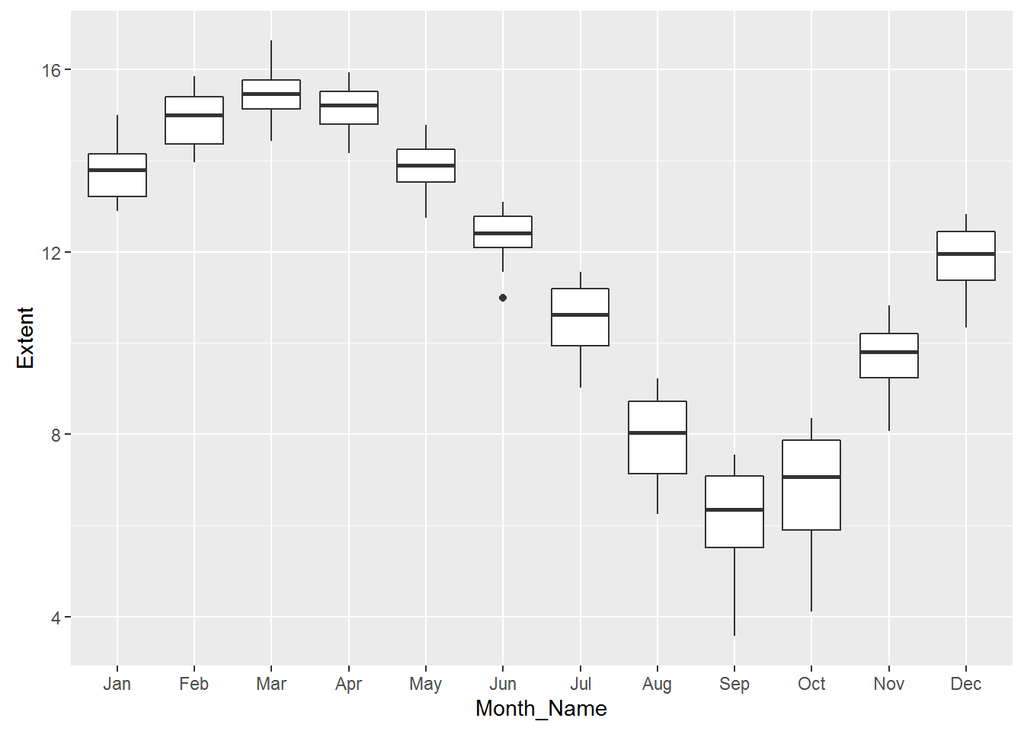

```r
#the plot will be called ice_box, and will use the ice data frame
ice_box <- ggplot(data = ice) +
#make a box plot where the x axis is the month name and the y is the extent of the sea ice
  geom_boxplot(mapping = aes(x = Month_Name, y = Extent))
ice_box
```

## 2.3

Now we will use `dplyr` to find the annual minimum sea ice.

```r
ice_min <- ice %>%
  #group by year so we can find the minimum value of each year
group_by(Year) %>%
 #use min function within summarise to create a table of years and their minimum ice extent.
summarise(Minimum_Extent = min(Extent))
```

We can also graph this with `ggplot` with a trendline

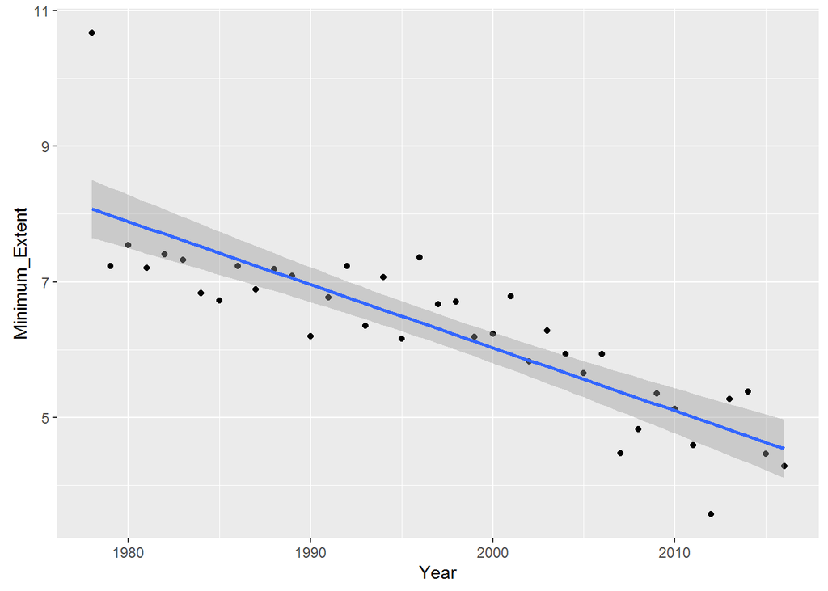

```r
#take the summary data
ice_min_plot <- ggplot(dat = ice_min,
                       mapping = aes(x = Year, y = Minimum_Extent)) +
  #make a plot
  geom_point() +
  #add a linear trendline
  stat_smooth(method = lm)
ice_min_plot
```